# ST661 - Group Project - London Marathon

Group 2: Sam Alexander White, Bimal Oommen John, Akshay Suresh Varma and Fernando Nicolas Szeliga Cabezuelo

2023-11-25

```r
#data downloading

remotes::install_github("nrennie/LondonMarathon")
data(winners, package = "LondonMarathon")
data(london_marathon, package = "LondonMarathon")

#Joint London Marathon and Winners by Year

joint_marathondata <- dplyr::full_join(london_marathon, winners, by="Year")

# Time conversion from fraction of days to h:m:s

# The time column is in fraction of days,so this was converted to seconds
time_in_seconds <- as.numeric(joint_marathondata$Time) * 24 * 60 * 60

# Formatting the time components
joint_marathondata$Time_Converted <- format(as.POSIXct(time_in_seconds,origin = "1970-01-01", tz = "UTC"), format = "%H:%M:%S")


# NEW VARIABLE: GEOGRAPHICAL LOCATION

winners_countries <- unique(joint_marathondata$Nationality)


geolocation_vector <- sapply(joint_marathondata$Nationality, function(x)
{

  if (x== "Norway" | x=="Ireland" |x== "Denmark" |x== "Poland" |x== "Sweden" | x=="Portugal" |x== "France" |x== "Germany" |x== "Belgium" |x== "Switzerland" |x== "Spain" |x== "Italy" | x=="Netherlands")
  {
    return("Rest of Europe")
  }
    else if (x== "United Kingdom")
  {
    return("United Kingdom")
  }
  else if (x== "United States" |x== "Canada" |x== "Mexico")
  {
    return("North America")
  }
  else if (x== "Japan" |x== "Soviet Union" |x== "China")
  {
    return("Asia")
  }
  else if (x== "Kenya" |x== "Morocco" |x== "Ethiopia")
  {
    return("Africa")
  }
  else (x == "Australia")
  {
    return("Oceania")
  }

})

joint_marathondata$`Winner's Geographical Location` <- geolocation_vector
```

### Introduction

#### Data Description

Since 1981, the London Marathon has stood as an iconic annual spectacle that has entranced participants from across the globe. Our extensive dataset covers the period from 1981 to 2023, delving deep into the intricacies of the marathon through two crucial components: “london_marathon” and “winners.” The former presents a comprehensive overview of the marathon’s yearly dynamics, encompassing vital statistics like number of applicants, accepted participants, starters, finishers, charitable contributions in millions of pounds (£MM), and a diverse array of chosen charities. The latter component, the “winners” dataset precisely details the successful individuals in four competition categories: Men, Women, Wheelchair Men, and Wheelchair Women. It doesn’t merely provide the champions’ names and nationalities but also uncovers their remarkable completion times.

#### Data Overview

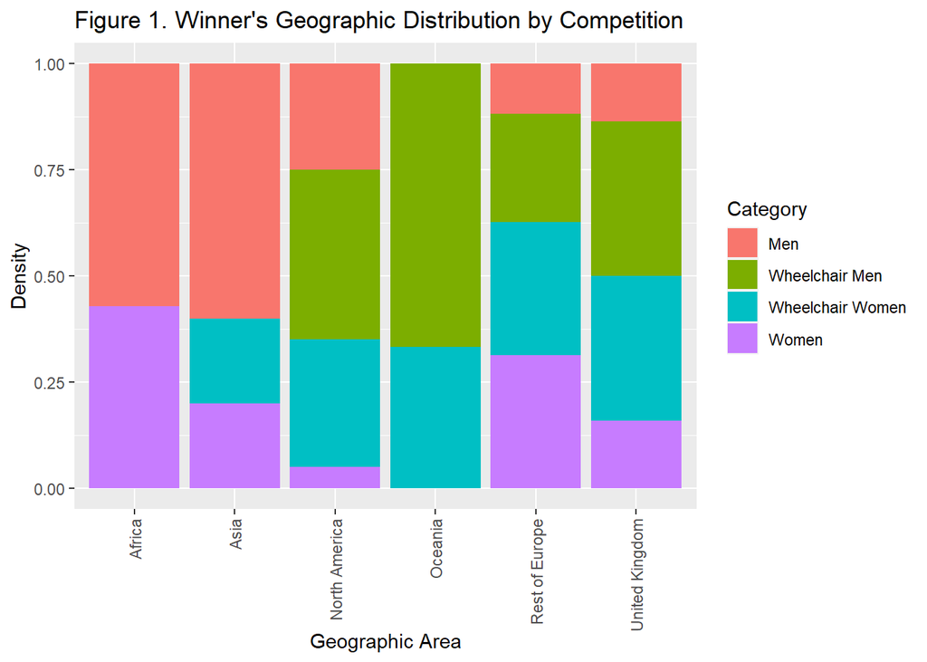

…

```r
ggplot(data = joint_marathondata) +
  geom_bar(mapping = aes(x = `Winner's Geographical Location`, fill=Category), position = "fill") + labs(x= "Geographic Area", y= "Density", title =  "Figure 1. Winner's Geographic Distribution by Competition") + theme(axis.text.x = element_text(angle = 90, vjust = 0.5, hjust = 1))
```

The data highlights the distribution of victories in various categories at the London Marathon. In the Men’s competition, Kenya secures the lead with 17 wins, followed by the United Kingdom with 6 and Norway with 1. Simultaneously, in the Women’s division, Kenya maintains its dominance with 14 victories, while the United Kingdom and Norway follow with 7 and 6 wins, respectively.

#### Research Questions

The following three research questions are being assessed in this report:

**Research Question 1: Are the Kenyan winners the fastest overall in the male and female competition?**

As outlined in the data overview, Kenya boasts the highest count of winners in both the male and female categories. Furthermore, the number of Kenyan winners surpasses that of the host country, the UK, by 50% or more. Consequently, the available data opens the possibility of examining whether Kenyan runners, being the most successful in terms of the number of victories, also exhibit the fastest overall performance. This analysis may shed light on whether speed contributes to Kenya’s prominence as the most successful country in these two competition categories.

**Research Question 2: In what ways has the London Marathon’s popularity fluctuated over time??**

**Research Question 3: Are men’s finish times similar to women’s finish time?**

### Analysis

##### **Research Q1** : are the Kenyan winners in the Male and Female categories the fastest?

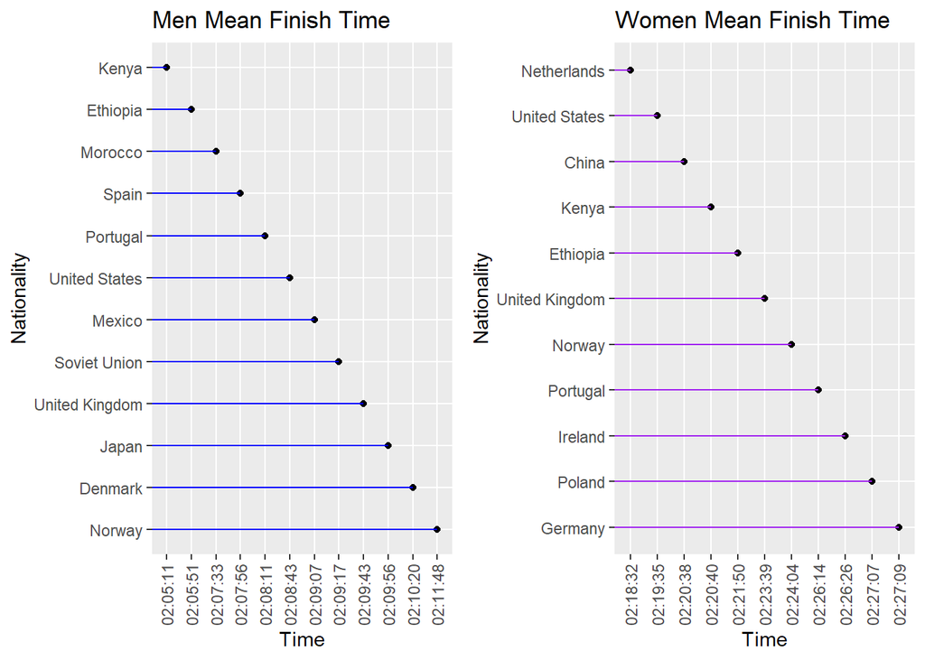

…

```r
# Time comparison by Nationality Plot. Category: Men

joint_marathondata |> filter(Category=="Men") |> group_by(Nationality) |> summarise(finish_time= mean(Time)) -> men_category


# The time column is in fraction of days,so this was converted to seconds
time_men <- as.numeric(men_category$finish_time) * 24 * 60 * 60

# Formatting the time components
men_category$time_conversion <- format(as.POSIXct(time_men,origin = "1970-01-01", tz = "UTC"), format = "%H:%M:%S")

p_male <- ggplot(men_category, aes(x = reorder(Nationality,finish_time, decreasing=TRUE), y = time_conversion)) +  geom_point() + geom_segment(aes(xend = fct_reorder(Nationality,finish_time)), yend = 0, col = "blue") +
  coord_flip() + theme(axis.text.x = element_text(angle = 90, vjust = 0.5, hjust = 1)) + labs(x= "Nationality", y= "Time", title =  "Men Mean Finish Time")


# Time comparison by Nationality Plot. Category: Women

joint_marathondata |> filter(Category=="Women") |> group_by(Nationality) |> summarise(finish_time= mean(Time)) -> women_category


# The time column is in fraction of days,so this was converted to seconds
time_women <- as.numeric(women_category$finish_time) * 24 * 60 * 60

# Formatting the time components
women_category$time_conversion <- format(as.POSIXct(time_women,origin = "1970-01-01", tz = "UTC"), format = "%H:%M:%S")

p_female <- ggplot(women_category, aes(x = reorder(Nationality,finish_time, decreasing=TRUE), y = time_conversion)) +
  geom_point() + geom_segment(aes(xend = fct_reorder(Nationality,finish_time)), yend = 0, col = "purple") +
  coord_flip() + theme(axis.text.x = element_text(angle = 90, vjust = 0.5, hjust = 1)) + labs(x= "Nationality",y= "Time", title =  "Women Mean Finish Time")


grid.arrange(p_male, p_female, ncol = 2)
```

**Research Q2** : In what ways has the London Marathon’s popularity fluctuated over time?

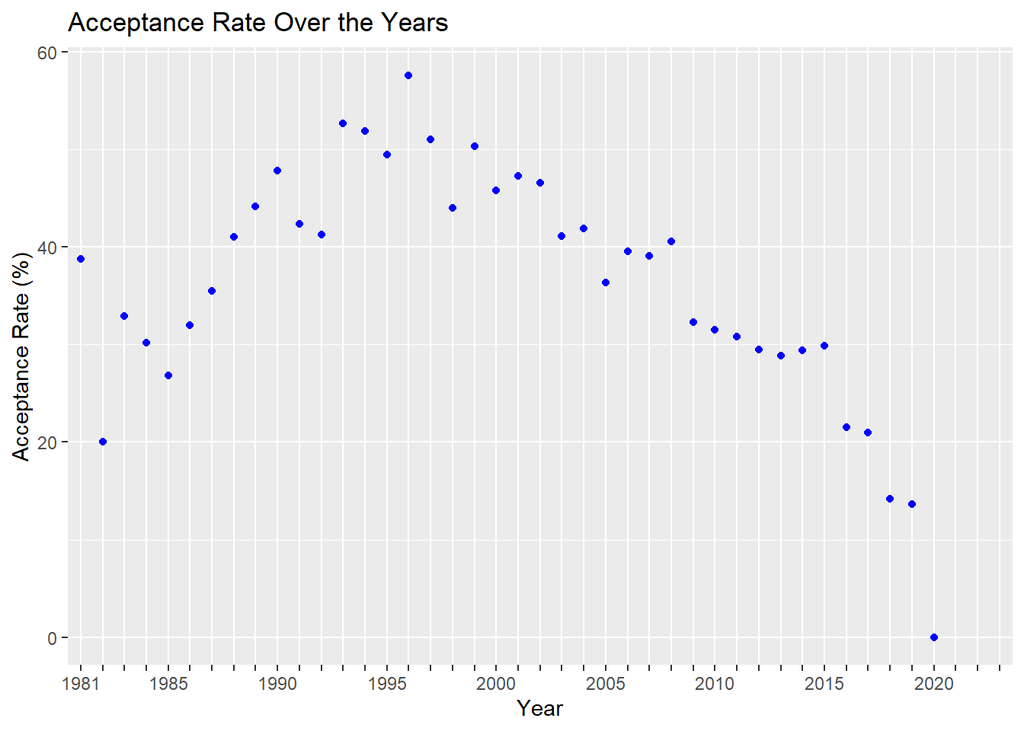

```r
joint_marathondata$Acceptance_Rate <- (joint_marathondata$Accepted / joint_marathondata$Applicants) * 100
subset_years <- c(1981,1985,1990, 1995, 2000, 2005, 2010, 2015, 2020)
ggplot(joint_marathondata, aes(x = factor(Year), y = Acceptance_Rate)) +
  geom_line(color = "blue") +
  geom_point(color = "blue") +
  labs(title = "Acceptance Rate Over the Years",
       x = "Year",
       y = "Acceptance Rate (%)")+
  scale_x_discrete(labels = function(x) ifelse(as.numeric(x) %in% subset_years, x, ""))
```